# R Notebook following ModernStatisticswithR.com

## Exercise

1. Using the msleep data, create a plot of log-transformed body weight versus log-transformed brain weight. Use total sleep time to set the colours of the points. Change the text on the axes to something informative.

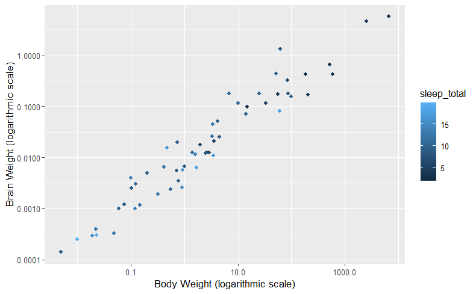

```r
ggplot(msleep, aes(bodywt, brainwt, colour = sleep_total)) +
  geom_point() +
  labs(
    x = "Body Weight (logarithmic scale)",
    y = "Brain Weight (logarithmic scale)"
  ) +
  scale_x_log10() +
  scale_y_log10()
```

- #facetting = creating a grid of plots corresponding to the different groups
  - adding the function `facet_wrap()` does this in ggplots

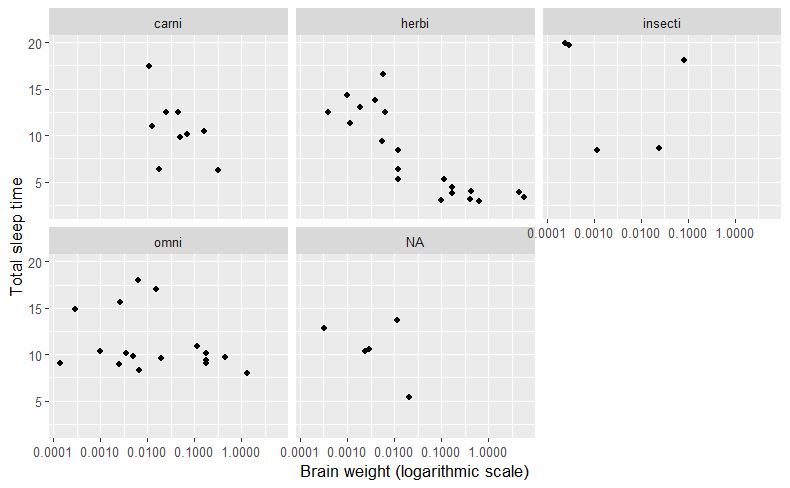

```r
ggplot(msleep, aes(brainwt, sleep_total)) +
  geom_point() +
  labs(x = "Brain weight (logarithmic scale)",
       y = "Total sleep time") +
  scale_x_log10() +
  facet_wrap(~ vore) # this means that for each unique `vore` there will be a different graph of plots
```

## Exercise

1. Create a scatterplot with bill_length_mm along the x-axis and flipper_length_mm along the y-axis, facetted by species.

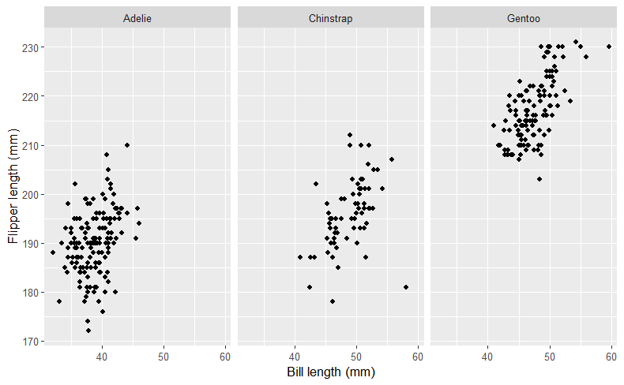

```r
ggplot(penguins, aes(bill_length_mm, flipper_length_mm)) +
  geom_point() +
  labs(x = "Bill length (mm)",
       y = "Flipper length (mm)") +
  facet_wrap(~ species)
```

2. Read the documentation for facet_wrap (?facet_wrap). How can you change the number of rows in the plot grid? Create the same plot as in part 1, but with 2 rows.

```r
?facet_wrap
```

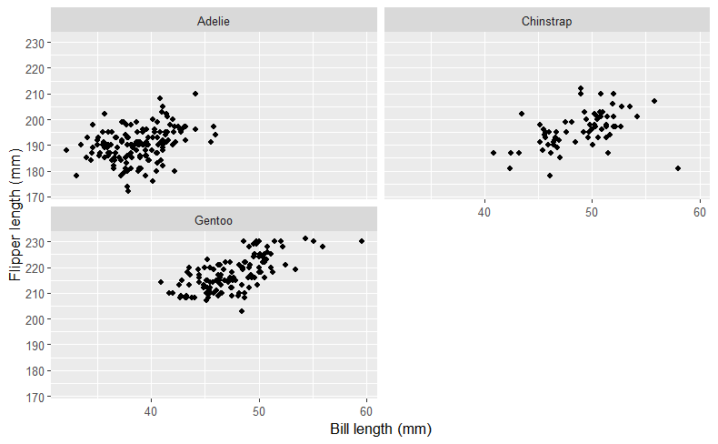

```r
ggplot(penguins, aes(bill_length_mm, flipper_length_mm)) +
  geom_point() +
  labs(x = "Bill length (mm)",
       y = "Flipper length (mm)") +
  facet_wrap(~ species,
             nrow = 2)
```

- box-and-whisker plots (aka boxplots) are good for comparing groups

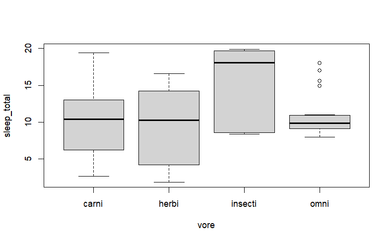

```r
# Base R:
boxplot(sleep_total ~ vore, data = msleep)
```

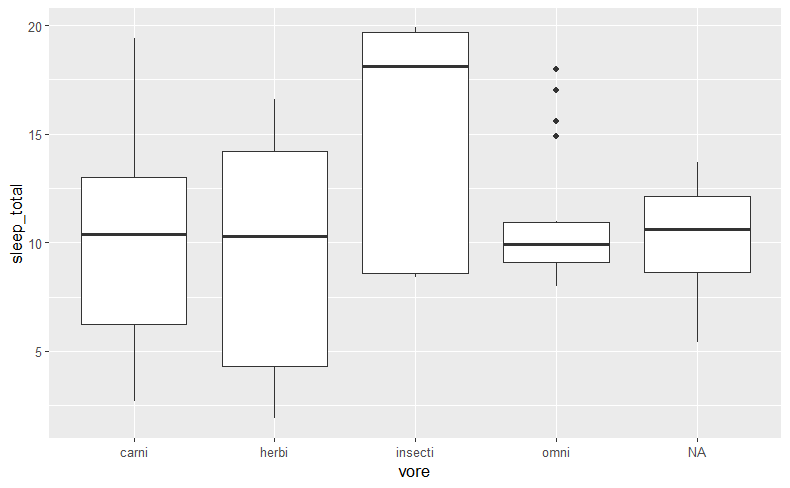

```r
# ggplot2:
ggplot(msleep, aes(vore, sleep_total)) +
  geom_boxplot()
```

- the information we are able to get from boxplots:
  - *Median*: thick black line inside the box
  - *First quartile*: bottom of the box
  - *Third quartile*: top of the box
  - *Minimum*: end of the line (“whisker”) that extends from the bottom of the box
  - *Maximum*: end of the line that extends from the top of the box
  - *Outliers*: observations that deviate too much from the rest are shown as separate points. These outliers are not included in the computation of the median, quartiles and the extremes

## Exercise

Using the penguins data, do the following: 1. Create boxplots of bill lengths, grouped by species.

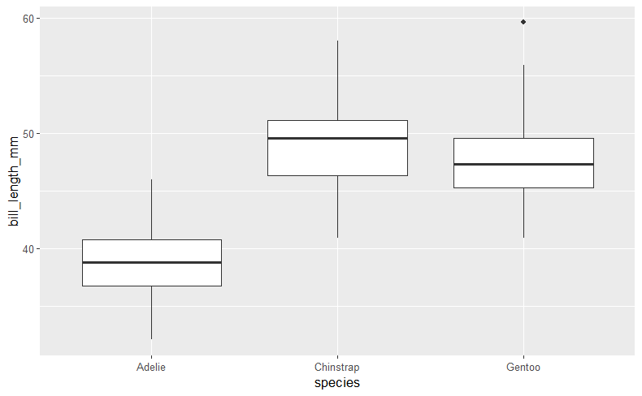

```r
ggplot(penguins, aes(species, bill_length_mm)) +
  geom_boxplot()
```

2. Read the documentation for geom_boxplot. How can you change the colours of the boxes and their outlines?

```r
?geom_boxplot
# colors are changes:
# geom_boxplot(fill = "white", colour = "red")
```

3. Add geom_jitter(size = 0.5, alpha = 0.25) to the plot. What happens?

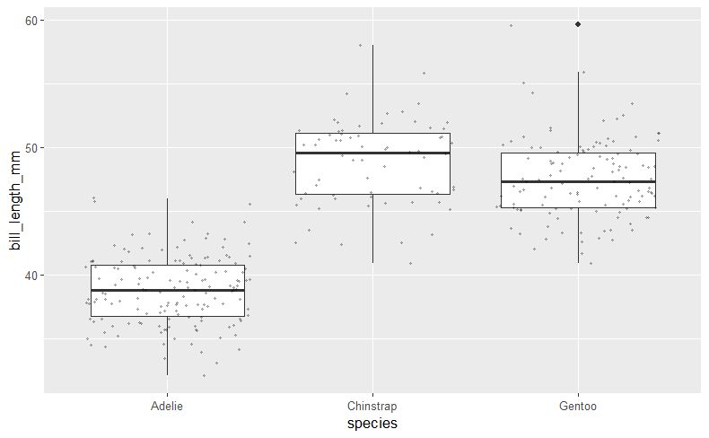

```r
ggplot(penguins, aes(species, bill_length_mm)) +
  geom_boxplot() +
  geom_jitter(size = 0.5, alpha = 0.25) # this is now going to add the points that are being summarized in the boxplot
```

- histograms are ways to show distributions of continuous variables by binning them and seeing the number of observations in each bin

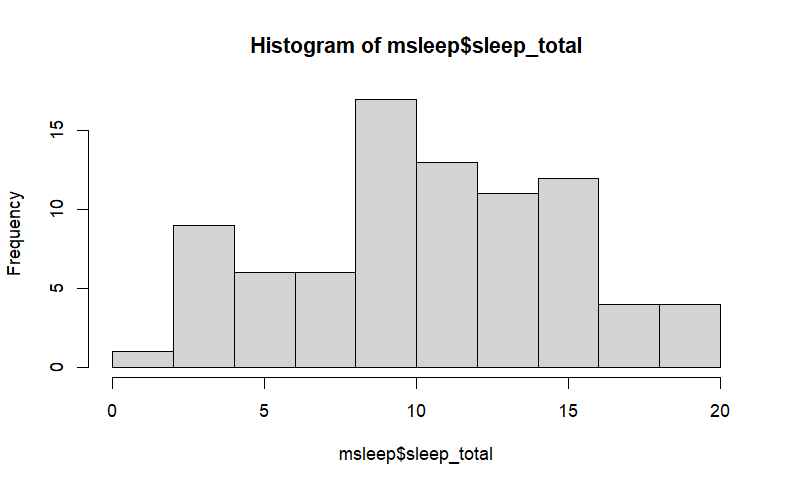

```r
# Base R:
hist(msleep$sleep_total)
```

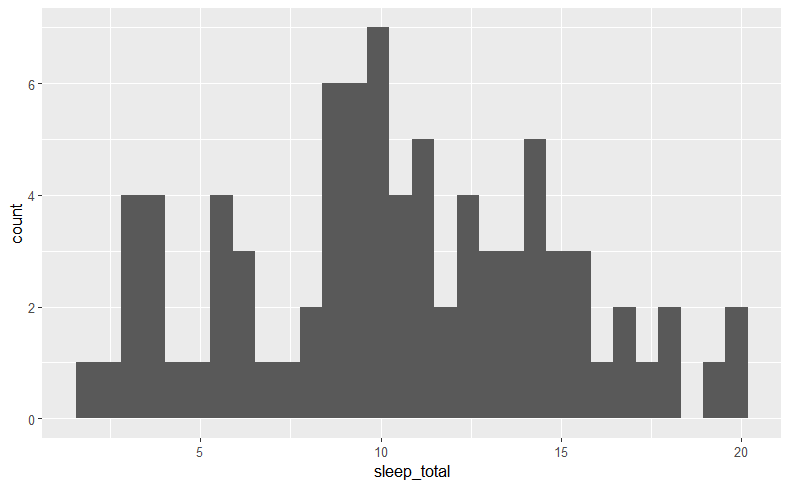

```r
# ggplot2:
ggplot(msleep, aes(sleep_total)) +
  geom_histogram()
```

## Exercise

Using the penguins data, do the following: 1. Create a histogram of bill lengths.

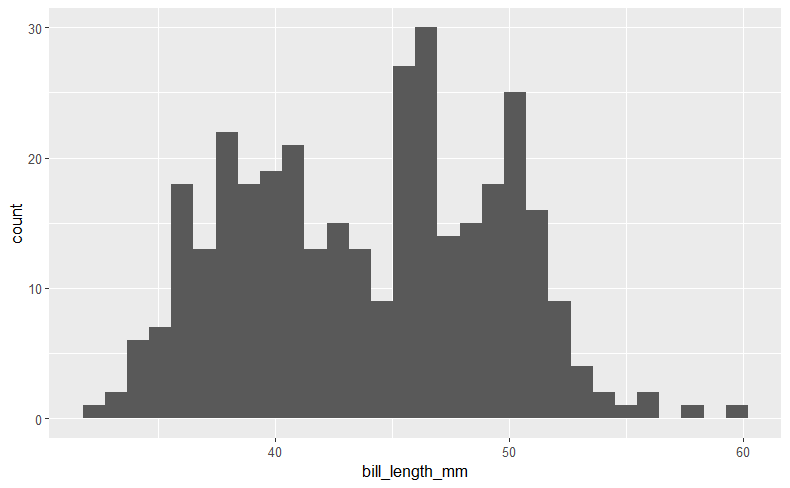

```r
ggplot(penguins, aes(bill_length_mm)) +
  geom_histogram()
```

2. Create histograms of bill lengths for different species, using facetting.

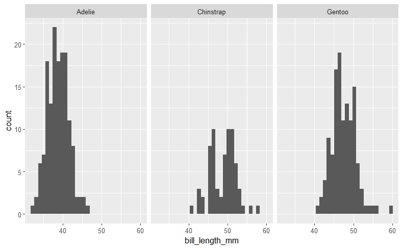

```r
ggplot(penguins, aes(bill_length_mm)) +
  geom_histogram() +
  facet_wrap(~ species)
```

3. Add a suitable argument to geom_histogram to add black outlines around the bars

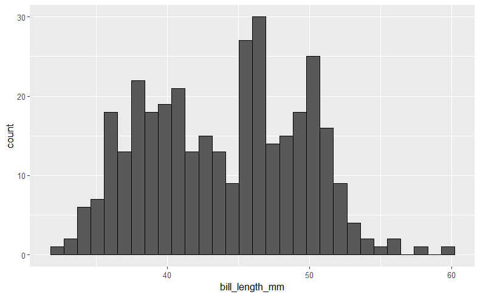

```r
ggplot(penguins, aes(bill_length_mm)) +
  geom_histogram(colour = "black")
```

- bar charts are mostly used for categorical variables and their counts

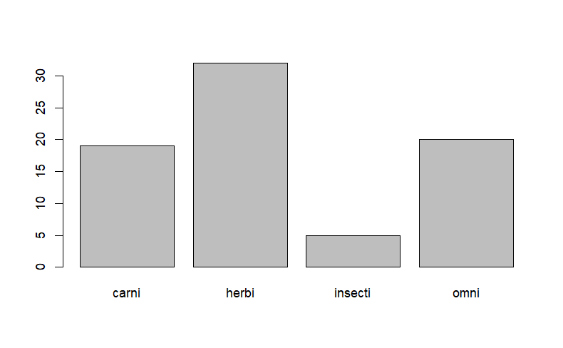

```r
# Base R:
barplot(table(msleep$vore))
```

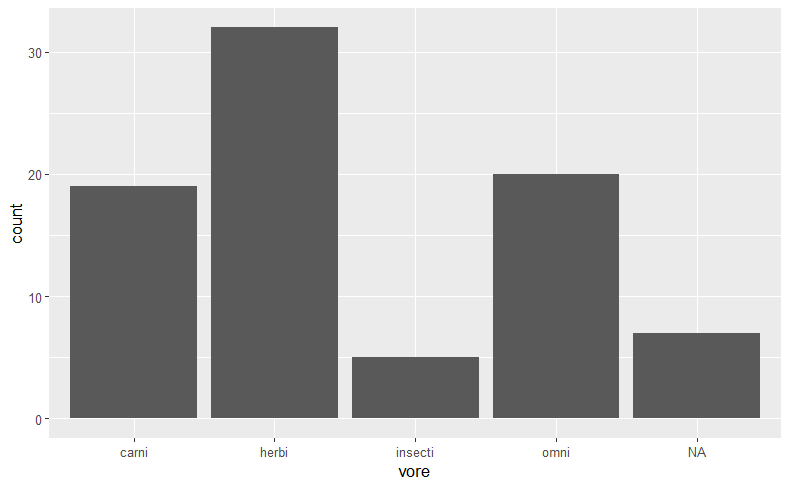

```r
# ggplot2:
ggplot(msleep, aes(vore)) +
  geom_bar()
```

- for stacked bar charts, ggplot2 is better for that and is done using `factor(1)` in the `aes()` function

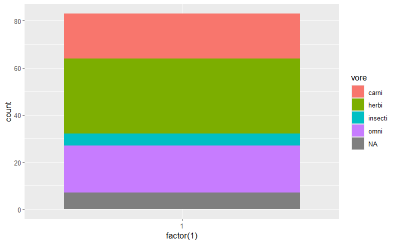

```r
ggplot(msleep, aes(factor(1), fill = vore)) +
  geom_bar()
```

## Exercise

Using the penguins data, do the following: 1. Create a bar chart of species.

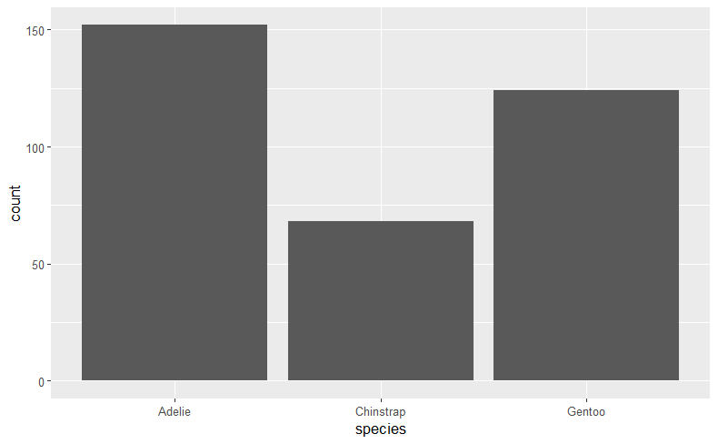

```r
ggplot(penguins, aes(species)) +
  geom_bar()
```

2. Add different colours to the bars by adding a fill argument to geom_bar.

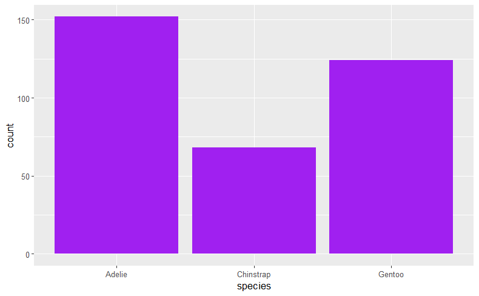

```r
ggplot(penguins, aes(species)) +
  geom_bar(fill = "purple")
```

3. Check the documentation for geom_bar. How can you decrease the width of the bars?

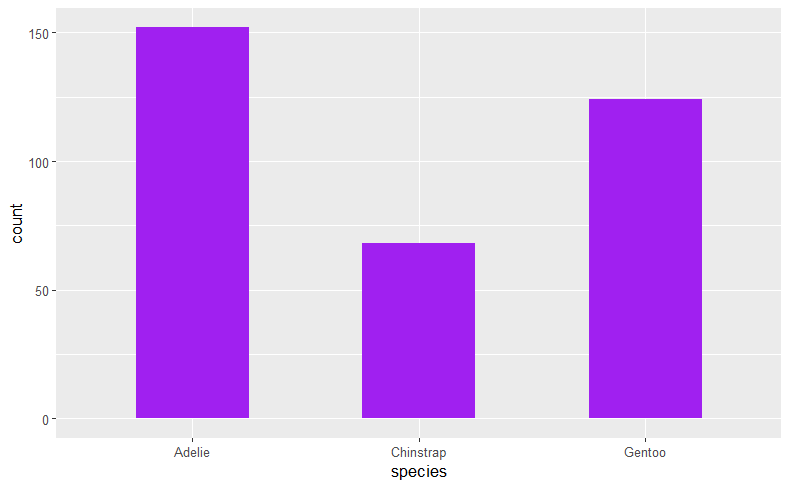

```r
ggplot(penguins, aes(species)) +
  geom_bar(fill = "purple", width = 0.5)
```

4. Return to the code you used for part 1. Add fill = sex to the aes. What happens?

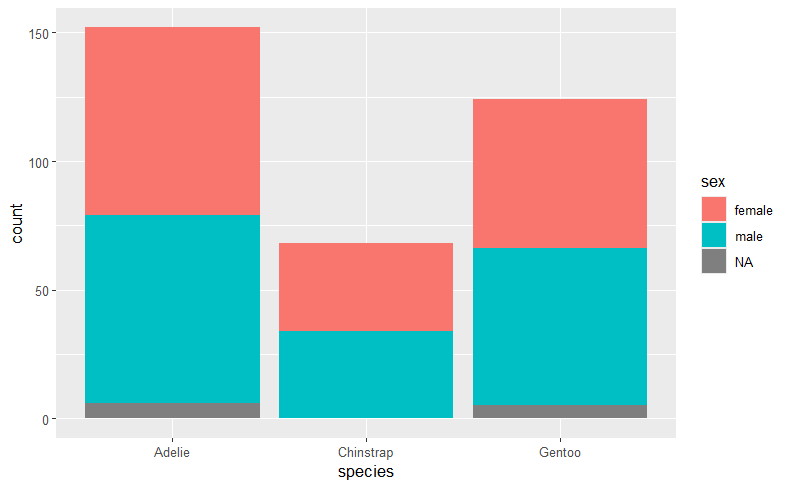

```r
ggplot(penguins, aes(species, fill = sex)) +
  geom_bar()
```

5. Next, add position = “dodge” to geom_bar. What happens?

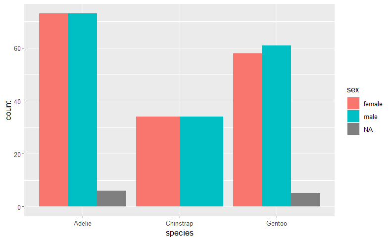

```r
ggplot(penguins, aes(species, fill = sex)) +
  geom_bar(position = "dodge") # this will have the "sex" types as bars side by side for the species instead of stacked
```

6. Add coord_flip() to the plot. What happens?

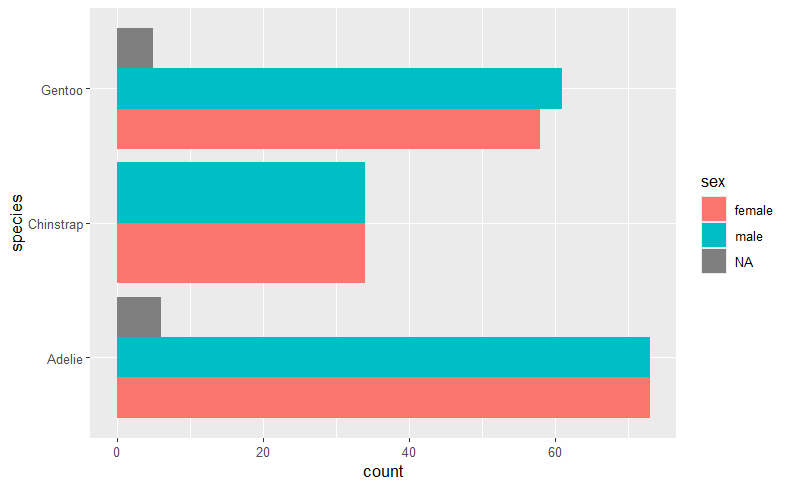

```r
ggplot(penguins, aes(species, fill = sex)) +
  geom_bar(position = "dodge") +
  coord_flip() # this is now going to make the graph horizontal instead of vertical
```

- now the important part is saving the plots which you can save as a variable name

```r
myPlot <- ggplot(msleep, aes(sleep_total, sleep_rem)) +
  geom_point()
```

- you can even add additional elements to the plot even after you save it

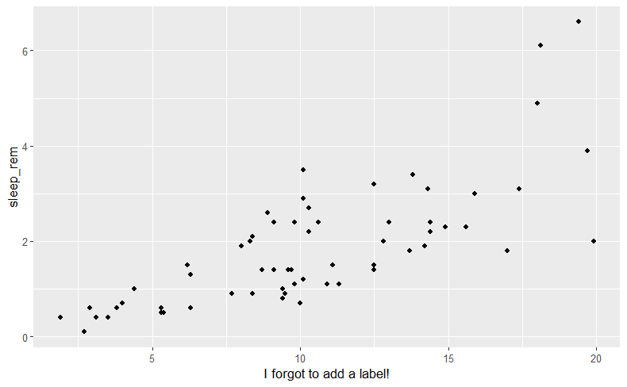

```r
myPlot + labs(x = "I forgot to add a label!")
```

- then to save the image itself, use the function `ggsave` and you can even use the option width and height arguments to specify the size

```r
ggsave("sample_plot.jpg", myPlot, width = 5, height = 5)
```

R has six basic data types. For most people, it suffices to know about the first three in the list below: - *numeric*: numbers like 1 and 16.823 (sometimes also called double). - *logical*: true/false values (Boolean): either TRUE or FALSE. - *character*: text, e.g., “a”, “Hello! I’m Ada.” and “name@domain.com”. - *integer*: integer numbers, denoted in R by the letter L: 1L, 55L. - *complex*: complex numbers, like 2+3i. Rarely used in statistical work. - *raw*: used to hold raw bytes.

- using the `class()` function, you can see what the data type of any variable is:

```r
x <- 6
y <- "Scotland"
z <- TRUE

class(x)
```

```
[1] "numeric"
```

```r
class(y)
```

```
[1] "character"
```

```r
class(z)
```

```
[1] "logical"
```

```r
numbers <- c(6, 9, 12)
class(numbers)
```

```
[1] "numeric"
```

```r
all_together <- c(x, y, z)
all_together
```

```
[1] "6"        "Scotland" "TRUE"
```

```r
class(all_together)
```

```
[1] "character"
```

- not only are there different data types but there are different ways to store data:
  - *matrix*: a table where all columns must contain objects of the same type (e.g., all numeric or all character). Uses less memory than other types and allows for much faster computations, but it is difficult to use for certain types of data manipulation, plotting and analyses.
  - *data.frame*: the most common type, where different columns can contain different types (e.g., one numeric column, one character column).
  - *data.table*: an enhanced version of data.frame.
  - *tbl_df* (“tibble”): another enhanced version of data.frame.

```r
# First, an example of data stored in a matrix:
?WorldPhones
class(WorldPhones)
```

```
[1] "matrix" "array"
```

```r
View(WorldPhones)

# Next, an example of data stored in a data frame:
?airquality
class(airquality)
```

```
[1] "grouped_df" "tbl_df"     "tbl"        "data.frame"
```

```r
View(airquality)

# Finally, an example of data stored in a tibble:
library(ggplot2)
?msleep
class(msleep)
```

```
[1] "tbl_df"     "tbl"        "data.frame"
```

```r
View(msleep)
```

- there are ways to convert objects into other types

```r
WorldPhonesDF <- as.data.frame(WorldPhones)
class(WorldPhonesDF)
```

```
[1] "data.frame"
```

```r
airqualityMatrix <- as.matrix(airquality)
class(airqualityMatrix)
```

```
[1] "matrix" "array"
```